# Group_4_Sprint_5_Development_v5

Artificial Intelligence for Business Decisions and Transformation

CSCN8030 - Spring 2024 - Section 2

Professor: Glaucia Melo dos Santos, PhD

Group 4 - Members:

Krishna Kumar, Hemasree  
Shijin, Jency  
Fernandez, Arcadio

## **Sprint 5 Development:**

# **Project: TikTok - User Interest Profiling for TikTok Users Based on Review Text Analysis**

## **Project Overview:**

This project aims to develop a comprehensive system to profile TikTok users based on their app review texts. By analyzing the textual content of user reviews, we intend to categorize users into specific interest groups such as Entertainment Enthusiasts, Educational Seekers, Lifestyle Admirers, and more. The ultimate goal is to provide insights into user preferences, which can be leveraged for personalized content recommendations, targeted marketing, and improving user engagement on the platform.

1. **TikTok Profiles Dataset:**

   This dataset contains various attributes related to TikTok user profiles. The key columns in this dataset are:

   **timestamp:** The date and time when the data was collected.

   **account_id:** A unique identifier for each TikTok user account.

   **nickname:** The display name of the user.

   **biography:** The bio section of the user's profile, where they describe themselves.

   **awg_engagement_rate:** The average engagement rate for the user's content.

   **comment_engagement_rate:** The engagement rate based on comments.

   **like_engagement_rate:** The engagement rate based on likes.

   **bio_link:** A URL link provided in the user's bio.

   **is_verified:** A boolean indicating if the user is verified.

   **followers:** The number of followers the user has.

   **following:** The number of accounts the user is following.

   **likes:** The total number of likes received by the user's content.

   **videos_count:** The number of videos uploaded by the user.

   **create_time:** The account creation date and time.

   **id:** A secondary identifier for the user.

   **top_videos:** Links or identifiers to the user's top videos.

   **url:** The URL to the user's profile.

   **profile_pic_url:** The URL to the user's profile picture.
2. **TikTok App Reviews Dataset:**

   This dataset includes user reviews for the TikTok app. The key columns in this dataset are:

   **review_id:** A unique identifier for each review.

   **review_text:** The textual content of the user's review.

   **upvotes:** The number of upvotes the review has received.

   **app_version:** The version of the TikTok app at the time of the review.

   **posted_date:** The date when the review was posted.

```python
!
!pip install --upgrade pandas transformers
!pip install textblob
```

```python
!pip install contractions emoji
```

```python
# Importing the libraries
import numpy as np
import pandas as pd
from textblob import TextBlob
import seaborn as sns
import matplotlib.pyplot as plt
import re
import contractions
from nltk.tokenize import word_tokenize
from nltk.corpus import stopwords
from nltk.stem import WordNetLemmatizer
import emoji
import nltk
```

```python
import pandas as pd

# Define the file paths
profiles_file_path = r'C:\Users\arcad\Labs_term2\TikTok\TikTok profiles dataset (Public web data).csv'
reviews_file_path = r'C:\Users\arcad\Labs_term2\TikTok\tiktok_app_reviews.csv'

# Read the CSV files
df_tiktok_profiles = pd.read_csv(profiles_file_path)
df_tiktok_app_reviews = pd.read_csv(reviews_file_path)

# Display the first few rows of each DataFrame
print(df_tiktok_profiles.head())
print(df_tiktok_app_reviews.head())
```

```
    timestamp      account_id              nickname  \
0  2023-08-01      a.r.m.y664                ❤️❤️❤️
1  2023-08-01           a2_9r       ايمن الفستقي🍺🥂🥃
2  2023-07-30     ti.po.check                   All
3  2023-08-06  nutrifersanort  L.N Fernanda Sánchez
4  2023-07-25          bhgdee                    D💲

                                           biography  awg_engagement_rate  \
0  nazywam się Basia 🇵🇱+🇺🇸 moja mama jest z USA 🖤...             0.049630
1                       حسابي الاصلي تيكتككك(_8_ytp_             0.059322
2  Активный пользователь ТикТока 🌝\nМеня зовут BD...             0.001399
3                 Nutrióloga, educadora en diabetes.             0.469767
4  Ig-bhg.dee📸\nSc-dannieo2099 👻\nFb- frank matth...             0.122283

   comment_engagement_rate  like_engagement_rate bio_link  is_verified  \
```

[output cut: 53 more lines]

```python
display(df_tiktok_app_reviews)
```

|  | review_id | review_text | upvotes | app_version | posted_date |
| --- | --- | --- | --- | --- | --- |
| 0 | gp:AOqpTOGSsGv5rOA79ttW2LE0FeMYvkdUuXRMTfbyMk0... | It is an excellent solution to finding videos ... | 402 | 21.2.5 | 2021-09-20 07:50:23 |
| 1 | gp:AOqpTOEDQ9__FJihY_0V4iwqy4P2OK8tGVR1tFBixYb... | Great app works really well so many features s... | 67 | 21.2.5 | 2021-09-19 23:10:47 |
| 2 | gp:AOqpTOEGEfr8TL0iKTlpbTDeM8P7HywlMmP9CkHMoaT... | I down loaded app but didnt work . i love this... | 24 | 21.2.5 | 2021-09-19 08:59:34 |
| 3 | gp:AOqpTOGZBDl9dpghmb43Mx1tnlWCOjNXyuVn5Mxf49c... | IT A GREAT APP AND FUN TO USE! HOWEVER ARBITRA... | 18 | 21.2.5 | 2021-09-19 16:34:43 |
| 4 | gp:AOqpTOFioH3wud_JnC4aPCG4p7s5DEEN2yZAWNXdRJj... | Currently it's working good for me except a fe... | 232 | 21.1.41 | 2021-09-14 06:35:02 |
| ... | ... | ... | ... | ... | ... |
| 3646471 | gp:AOqpTOEEOr8NzYiOHyv78HwG4RtMidvhF0T8Av8cV94... | Nicr | 0 | NaN | 2021-07-28 19:06:32 |
| 3646472 | gp:AOqpTOGyGnaNxjtd_frHLZSSDEkRo80vUrqsZ1kaSk1... | wow | 0 | NaN | 2019-05-06 03:59:08 |
| 3646473 | gp:AOqpTOGxyWD7luZFV-i4ZMj-x6UWrVle67pnwx-Klzx... | tq | 0 | NaN | 2019-04-11 09:20:53 |
| 3646474 | gp:AOqpTOEdh8QQ3HTkcuZZPQnTLZTpk6d49pGB9_Zx0nO... | Owsm | 0 | NaN | 2019-09-14 04:13:30 |
| 3646475 | gp:AOqpTOEbcTyAsdBIJDmV9AgErmyPYiIHOp4QtLrq9qt... | niceapps | 0 | NaN | 2021-08-04 14:37:54 |

3646476 rows × 5 columns

```python
display(df_tiktok_profiles)
```

|  | timestamp | account_id | nickname | biography | awg_engagement_rate | comment_engagement_rate | like_engagement_rate | bio_link | is_verified | followers | following | likes | videos_count | create_time | id | top_videos | url | profile_pic_url |
| --- | --- | --- | --- | --- | --- | --- | --- | --- | --- | --- | --- | --- | --- | --- | --- | --- | --- | --- |
| 0 | 2023-08-01 | a.r.m.y664 | ❤️❤️❤️ | nazywam się Basia 🇵🇱+🇺🇸 moja mama jest z USA 🖤... | 0.049630 | 0.004473 | 0.045157 | NaN | False | 1755 | 1443 | 1586 | 20 | NaN | 6794435137251820550 | https://www.tiktok.com/@a.r.m.y664/video/68236... | https://www.tiktok.com/@a.r.m.y664 | https://p77-sign-va.tiktokcdn.com/musically-ma... |
| 1 | 2023-08-01 | a2_9r | ايمن الفستقي🍺🥂🥃 | حسابي الاصلي تيكتككك(_8_ytp_ | 0.059322 | 0.004358 | 0.054964 | NaN | False | 354 | 1422 | 3843 | 225 | NaN | 7019722709156430853 | https://www.tiktok.com/@a2_9r/video/7218348887... | https://www.tiktok.com/@a2_9r | https://p16-sign-va.tiktokcdn.com/tos-maliva-a... |
| 2 | 2023-07-30 | ti.po.check | All | Активный пользователь ТикТока 🌝\nМеня зовут BD... | 0.001399 | 0.000058 | 0.001341 | NaN | False | 1960 | 243 | 24000 | 228 | NaN | 6826677567140873222 | https://www.tiktok.com/@ti.po.check/video/6984... | https://www.tiktok.com/@ti.po.check | https://p58-sign-sg.tiktokcdn.com/aweme/720x72... |
| 3 | 2023-08-06 | nutrifersanort | L.N Fernanda Sánchez | Nutrióloga, educadora en diabetes. | 0.469767 | 0.004651 | 0.465116 | NaN | False | 43 | 41 | 100 | 5 | NaN | 6809397670235407365 | https://www.tiktok.com/@nutrifersanort/video/7... | https://www.tiktok.com/@nutrifersanort | https://p16-sign-va.tiktokcdn.com/tos-maliva-a... |
| 4 | 2023-07-25 | bhgdee | D💲 | Ig-bhg.dee📸\nSc-dannieo2099 👻\nFb- frank matth... | 0.122283 | 0.008152 | 0.114130 | NaN | False | 276 | 2262 | 126 | 4 | NaN | 6810526136080483334 | https://www.tiktok.com/@bhgdee/video/719722663... | https://www.tiktok.com/@bhgdee | https://p16-sign.tiktokcdn-us.com/tos-useast5-... |
| ... | ... | ... | ... | ... | ... | ... | ... | ... | ... | ... | ... | ... | ... | ... | ... | ... | ... | ... |
| 995 | 2023-07-30 | lpk.jp | Hinode Abadi Indonesia | Yayasan Hinode (SO)\nLembaga Pelatihan Bahasa ... | 0.076391 | 0.004584 | 0.071807 | NaN | False | 956 | 294 | 4028 | 110 | NaN | 6950843413404435457 | https://www.tiktok.com/@lpk.jp/video/726037681... | https://www.tiktok.com/@lpk.jp | https://p16-sign-sg.tiktokcdn.com/aweme/720x72... |
| 996 | 2023-07-30 | loup_32 | loup _06.18 | adore stanger thanks et Zepeto | 0.463636 | 0.004545 | 0.459091 | NaN | False | 55 | 226 | 101 | 4 | NaN | 6893197159820297218 | https://www.tiktok.com/@loup_32/video/71592449... | https://www.tiktok.com/@loup_32 | https://p16-sign-va.tiktokcdn.com/tos-maliva-a... |
| 997 | 2023-08-12 | djbigkev | DJ_BigKev | 📍San Jose, CA\nGood Music & Good Vibes\n🎧🎶🎉\nI... | 0.072184 | 0.001001 | 0.071183 | https://soundcloud.com/user-176043326 | False | 12100 | 256 | 102400 | 89 | NaN | 6710967357261530117 | https://www.tiktok.com/@djbigkev/video/7254431... | https://www.tiktok.com/@undefined | https://p16-sign-va.tiktokcdn.com/tos-maliva-a... |
| 998 | 2023-08-05 | fakhrulnaim13 | Fakhrul Naim | Rezeki di sawah. Suami Jamilah Khalil, Ayah ke... | 0.073662 | 0.003555 | 0.070107 | NaN | False | 2763 | 8059 | 18300 | 216 | NaN | 6880539217555358721 | https://www.tiktok.com/@fakhrulnaim13/video/72... | https://www.tiktok.com/@fakhrulnaim13 | https://p16-sign-useast2a.tiktokcdn.com/tos-us... |
| 999 | 2023-08-12 | cleanwithriaa | CleanWithRiaa | Lifestyle • Cleaning • Organizing\n25 \| Buffal... | 0.017046 | 0.000612 | 0.016434 | https://www.amazon.com/shop/cleanwithriaa | False | 5972 | 930 | 182100 | 332 | NaN | 7038705671954744367 | https://www.tiktok.com/@cleanwithriaa/video/72... | https://www.tiktok.com/@undefined | https://p16-sign.tiktokcdn-us.com/tos-useast5-... |

1000 rows × 18 columns

### 1. Perform Data integration by merging TikTok public user profiles and user reviews data by identifying common keys or fields.

```
Data Integration cannot be done as there is no common key between the two datasets
```

### 2. Clean the data by handling missing values, correcting data types, and ensuring data consistency.

```python
missing = pd.DataFrame(df_tiktok_profiles.isnull().sum()).reset_index()
missing.columns = ['Feature', 'Missing_Percent(%)']
missing['Missing_Percent(%)'] = missing['Missing_Percent(%)'].apply(lambda x: x / df_tiktok_profiles.shape[0] * 100)
missing.loc[missing['Missing_Percent(%)']>0,:]
```

|  | Feature | Missing_Percent(%) |
| --- | --- | --- |
| 3 | biography | 0.3 |
| 7 | bio_link | 80.9 |
| 13 | create_time | 100.0 |

```python
df_tiktok_profiles.drop(columns=['create_time','bio_link'],inplace=True)
```

```python
df_tiktok_profiles['biography'].fillna('No Bio', inplace=True)
```

```python
missing = pd.DataFrame(df_tiktok_app_reviews.isnull().sum()).reset_index()
missing.columns = ['Feature', 'Missing_Percent(%)']
missing['Missing_Percent(%)'] = missing['Missing_Percent(%)'].apply(lambda x: x / df_tiktok_app_reviews.shape[0] * 100)
missing.loc[missing['Missing_Percent(%)']>0,:]
```

|  | Feature | Missing_Percent(%) |
| --- | --- | --- |
| 1 | review_text | 0.004470 |
| 3 | app_version | 27.239148 |

```python
df_tiktok_app_reviews.dropna(inplace=True)
```

```python
df_tiktok_profiles.drop_duplicates(inplace=True)
df_tiktok_app_reviews.drop_duplicates(inplace=True)
```

```python
df_tiktok_app_reviews.info()
```

```
<class 'pandas.core.frame.DataFrame'>
Index: 2653068 entries, 0 to 3171175
Data columns (total 5 columns):
 #   Column       Dtype
---  ------       -----
 0   review_id    object
 1   review_text  object
 2   upvotes      int64
 3   app_version  object
 4   posted_date  object
dtypes: int64(1), object(4)
memory usage: 121.4+ MB
```

```python
df_tiktok_profiles.info()
```

```
<class 'pandas.core.frame.DataFrame'>
RangeIndex: 1000 entries, 0 to 999
Data columns (total 16 columns):
 #   Column                   Non-Null Count  Dtype
---  ------                   --------------  -----
 0   timestamp                1000 non-null   object
 1   account_id               1000 non-null   object
 2   nickname                 1000 non-null   object
 3   biography                1000 non-null   object
 4   awg_engagement_rate      1000 non-null   float64
 5   comment_engagement_rate  1000 non-null   float64
 6   like_engagement_rate     1000 non-null   float64
 7   is_verified              1000 non-null   bool
 8   followers                1000 non-null   int64
 9   following                1000 non-null   int64
 10  likes                    1000 non-null   int64
 11  videos_count             1000 non-null   int64
 12  id                       1000 non-null   int64
 13  top_videos               1000 non-null   object
 14  url                      1000 non-null   object
 15  profile_pic_url          1000 non-null   object
dtypes: bool(1), float64(3), int64(5), object(7)
memory usage: 118.3+ KB
```

### 3. Exploratory Data Analysis

### Sentiment Distribution:

**Positive Sentiment (71.4%):** The majority of the reviews are positive, indicating that most users have a favorable opinion of the TikTok app.

**Neutral Sentiment (26.7%):** A significant portion of the reviews are neutral, suggesting that these users have a balanced or indifferent view of the app.

**Negative Sentiment (1.9%):** A small fraction of the reviews are negative, indicating that a minority of users have issues or negative opinions about the app.

```python
# Sampling 10% of the dataset
df_tiktok_app_reviews_subset = df_tiktok_app_reviews.sample(frac=0.1, random_state=1)
```

```python
df_tiktok_app_reviews_subset
```

|  | review_id | review_text | upvotes | app_version | posted_date |
| --- | --- | --- | --- | --- | --- |
| 886099 | gp:AOqpTOFS8c4CjlxhB8CccTQcNUNVc_Pss2jviTDzcfD... | superb app superb app | 0 | 11.0.3 | 2019-05-01 10:34:51 |
| 3102904 | gp:AOqpTOFQOjsEm2BgRid9pWzSmBXNnseimSVO7h7j-HB... | Go follow me on musically it's - kattie.lemus | 0 | 4.10.8 | 2016-08-12 00:37:40 |
| 2887288 | gp:AOqpTOFKqDhKgZm6_WbSUtGxpTITqG2osp8JRGjWaP0... | Its just great | 0 | 7.6.0 | 2018-07-24 23:54:39 |
| 973688 | gp:AOqpTOGntRPMEBJU8a4h9NaNQvtAgRoi4MNJK2uvP7X... | Very funny app | 1 | 9.1.0 | 2018-11-15 22:25:14 |
| 1988830 | gp:AOqpTOEHe0Q0ruiZm_VL3XzrAq8pJquHaTD3agdvLZz... | Amazing | 0 | 17.2.4 | 2020-08-10 12:30:50 |
| ... | ... | ... | ... | ... | ... |
| 209833 | gp:AOqpTOH77_cOfTFQzptSV3OIogxOezGeVmtTqXQzKFV... | It's good . | 0 | 20.0.5 | 2021-07-08 03:08:12 |
| 1999389 | gp:AOqpTOHHXK4Jxx1PotpAVioVmtuKsC484tmt9PLH8i-... | Wait ver | 0 | 16.6.43 | 2020-07-31 10:14:08 |
| 2995518 | gp:AOqpTOH0ZQnPZpxosaXZ361LkI9SItwOZzrL3AmIUhu... | I love at | 0 | 5.7.3 | 2017-06-29 22:56:11 |
| 2164902 | gp:AOqpTOGlMbnlS-ieRstsitD4DKeSEQ5D56uLYsmLQop... | I rlly like tiktok bc it lets you meet new ppl... | 0 | 15.5.4 | 2020-03-31 10:06:22 |
| 2839730 | gp:AOqpTOGiuzY5aFadWa0j6kR5dTbe8xp__1mSJ-mmbyN... | Amazing app | 0 | 8.3.1 | 2018-11-06 20:45:24 |

265307 rows × 5 columns

```python
# Function to compute sentiment polarity
def get_sentiment(text):
    return TextBlob(text).sentiment.polarity

# Apply sentiment analysis to review_text
df_tiktok_app_reviews_subset['sentiment'] = df_tiktok_app_reviews_subset['review_text'].apply(lambda x: get_sentiment(str(x)))
```

```python
def categorize_sentiment(polarity):
    if polarity > 0:
        return 'Positive'
    elif polarity < 0:
        return 'Negative'
    else:
        return 'Neutral'

df_tiktok_app_reviews_subset['sentiment_class'] = df_tiktok_app_reviews_subset['sentiment'].apply(categorize_sentiment)
```

```python
# Count the occurrences of each sentiment category
sentiment_counts = df_tiktok_app_reviews_subset['sentiment_class'].value_counts()
```

```python
sentiment_counts
```

```
sentiment_class
Positive    189430
Neutral      70943
Negative      4934
Name: count, dtype: int64
```

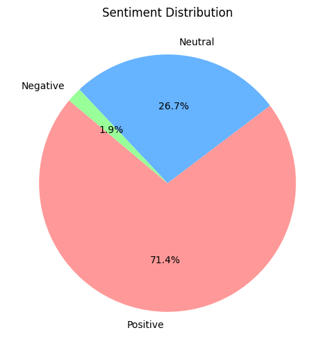

```python
plt.figure(figsize=(8, 6))
plt.pie(sentiment_counts, labels=sentiment_counts.index, autopct='%1.1f%%', startangle=140, colors=['#ff9999','#66b3ff','#99ff99'])
plt.title('Sentiment Distribution')
plt.show()
```

### Verified Vs Non-Verified Users

**Non-Verified Users:** The bar on the left (blue) shows the number of non-verified users, which is significantly higher, with a count of 981.

**Verified Users:** The bar on the right (orange) shows the number of verified users, which is much lower, with a count of 19.

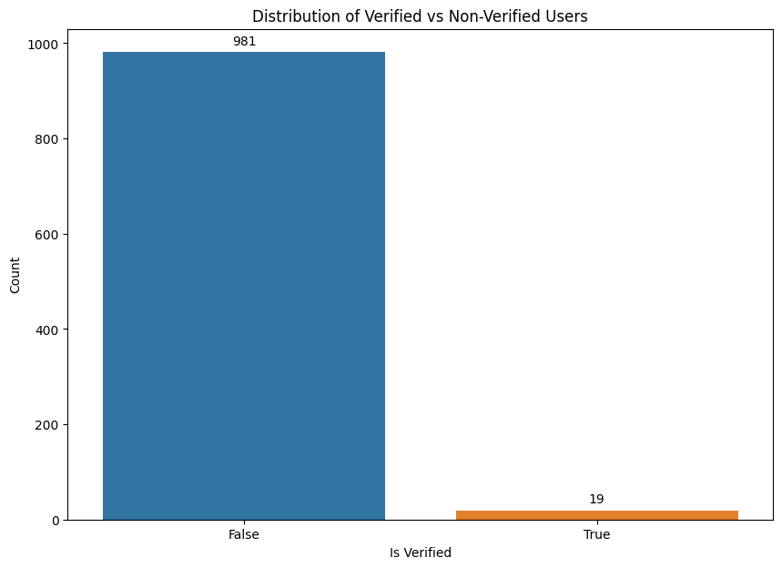

```python
# Distribution of verified vs non-verified users
plt.figure(figsize=(10, 7))
ax = sns.countplot(x='is_verified', data=df_tiktok_profiles)
# Get counts for annotations
counts = df_tiktok_profiles['is_verified'].value_counts()
for p in ax.patches:
    height = p.get_height()
    ax.text(p.get_x() + p.get_width() / 2., height +10, int(height), ha='center', va='bottom')

# Set title and labels
plt.title('Distribution of Verified vs Non-Verified Users')
plt.xlabel('Is Verified')
plt.ylabel('Count')

# Show the plot
plt.show()
```

### Correlation Heatmap

Followers and Likes (0.92): There is a very strong positive correlation between the number of followers and the number of likes. Users with more followers tend to receive more likes.

Videos Count and Likes (0.27): There is a moderate positive correlation between the number of videos uploaded and the number of likes. Users who upload more videos tend to receive more likes.

Followers and Videos Count (0.25): There is a moderate positive correlation between the number of followers and the number of videos uploaded.

Following and Followers (-0.052): There is a very weak negative correlation between the number of accounts a user is following and their number of followers.

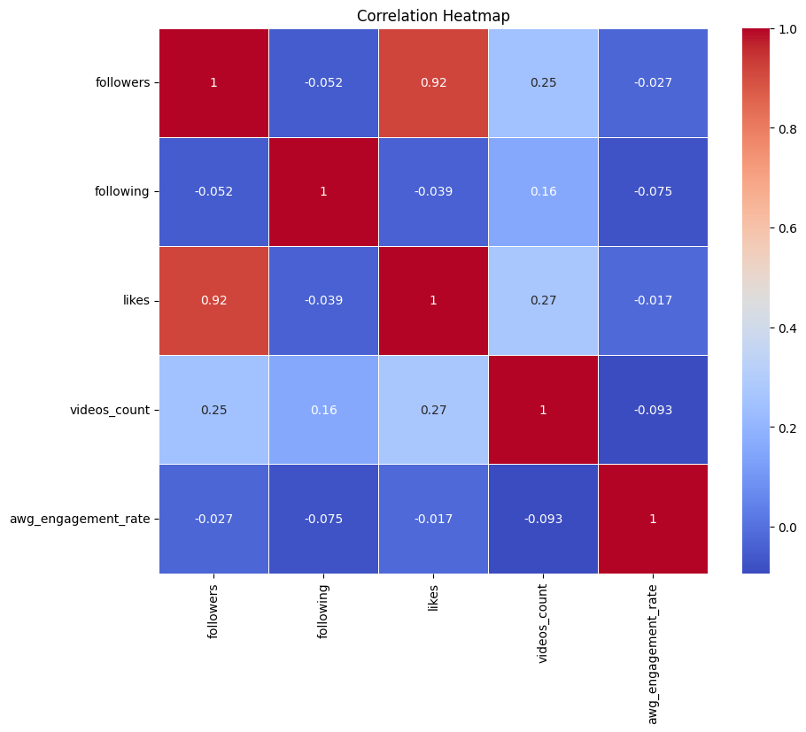

```python
# Correlation heatmap
plt.figure(figsize=(10, 8))
corr_matrix = df_tiktok_profiles[['followers', 'following', 'likes', 'videos_count', 'awg_engagement_rate']].corr()
sns.heatmap(corr_matrix, annot=True, cmap='coolwarm', linewidths=0.5)
plt.title('Correlation Heatmap')
plt.show()
```

### Top 10 Users based on most followers, following, likes,videos count

[output not shown]

[output cut: 77 more lines]

[output not shown]

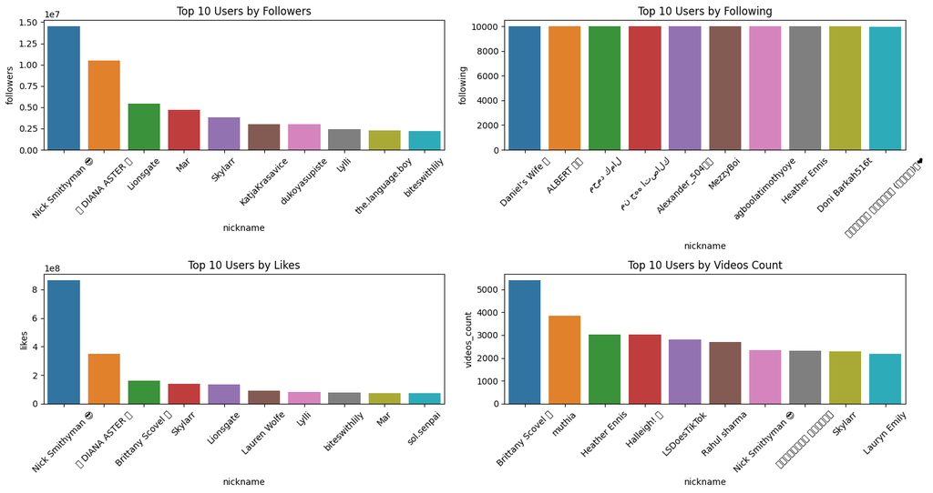

```python
# Heatmap of top 10 users with most followers
top_10_users = df_tiktok_profiles.nlargest(10, 'followers')
# Set the figure size
plt.figure(figsize=(15, 8))

# Bar plot for followers
plt.subplot(2, 2, 1)
sns.barplot(x='nickname', y='followers', data=top_10_users)
plt.xticks(rotation=45)
plt.title('Top 10 Users by Followers')

top_10_users = df_tiktok_profiles.nlargest(10, 'following')

# Bar plot for following
plt.subplot(2, 2, 2)
sns.barplot(x='nickname', y='following', data=top_10_users)
plt.xticks(rotation=45)
plt.title('Top 10 Users by Following')

top_10_users = df_tiktok_profiles.nlargest(10, 'likes')

# Bar plot for likes
plt.subplot(2, 2, 3)
sns.barplot(x='nickname', y='likes', data=top_10_users)
plt.xticks(rotation=45)
plt.title('Top 10 Users by Likes')

top_10_users = df_tiktok_profiles.nlargest(10, 'videos_count')

# Bar plot for videos count
plt.subplot(2, 2, 4)
sns.barplot(x='nickname', y='videos_count', data=top_10_users)
plt.xticks(rotation=45)
plt.title('Top 10 Users by Videos Count')

plt.tight_layout()
plt.show()
```

### Average Engagement rate by Verification status

The bar chart showing the average engagement rate for verified and non-verified TikTok users.

**Non-Verified Users( false):** shows the average engagement rate for non-verified users, which is significantly higher, around 0.55.

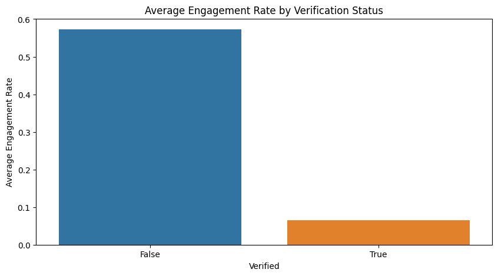

```python
# Bar plot of average engagement rate by verification status
plt.figure(figsize=(10, 5))
avg_engagement_rate = df_tiktok_profiles.groupby('is_verified')['awg_engagement_rate'].mean().reset_index()
sns.barplot(x='is_verified', y='awg_engagement_rate', data=avg_engagement_rate)
plt.title('Average Engagement Rate by Verification Status')
plt.xlabel('Verified')
plt.ylabel('Average Engagement Rate')
plt.show()
```

```python
!pip install wordcloud
```

### Word Cloud

The word cloud visualizes the most frequently occurring words in the TikTok app reviews dataset.

**Larger words in the word cloud** represent words that **appear more frequently** in the reviews, while **smaller words are less frequent**.

**Words like "app," "good," "love," "TikTok," "nice," "fun," and "amazing"** appear prominently in the word cloud.

These words suggest that users generally **have positive sentiments towards the app, as indicated by words like "good," "love," "fun," "amazing," and "nice.**

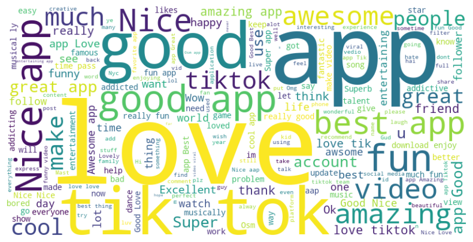

```python
from wordcloud import WordCloud

# Combine all review texts
text = ' '.join(df_tiktok_app_reviews_subset['review_text'].dropna())

# Generate a word cloud
wordcloud = WordCloud(width=800, height=400, background_color='white').generate(text)

# Display the word cloud
plt.figure(figsize=(10, 5))
plt.imshow(wordcloud, interpolation='bilinear')
plt.axis('off')
plt.show()
```

### 4. Preprocess the user reviews or any other text data by cleaning, tokenizing, lemmatizing, and removing stop words.

```python
# Updated dictionary of short forms and their expansions
short_form_dict = {
    "msg": "message",
    "txt": "text",
    "dm": "direct message",
    "u": "you",
    "ur": "your",
    "r": "are",
    "k": "okay",
    "omg": "oh my god",
    "idk": "I don't know",
    "brb": "be right back",
    "btw": "by the way",
    "gr8": "great",
    "b4": "before",
    "pls": "please",
    "plz": "please",
    "thx": "thanks",
    "thxs": "thanks",
    "be coz": "because",
    "ty": "thank you",
    "y": "why",
    "cya": "see you",
    "ttyl": "talk to you later",
    "imo": "in my opinion",
    "fyi": "for your information",
    "asap": "as soon as possible",
    "bff": "best friends forever",
    "lol": "laugh out loud",
    "np": "no problem",
    "smh": "shaking my head",
    "tq": "thank you",
    "owsm": "awesome",
    "wow": "wow",
    "nicr": "nice",
    "ppl": "people",
    "bc": "because"
    # Add more short forms as needed
}

# Function to expand short forms
def expand_short_forms(text, short_form_dict):
    words = text.split()
    expanded_words = [short_form_dict.get(word.lower(), word) for word in words]
    expanded_text = ' '.join(expanded_words)
    return expanded_text

# Function to remove emojis
def remove_emojis(text):
    return emoji.replace_emoji(text, replace='')

# Function to remove hashtags and mentions
def remove_hashtags_mentions(text):
    text = re.sub(r'@\w+', '', text)  # Remove mentions
    text = re.sub(r'#\w+', '', text)  # Remove hashtags
    return text

    return preprocessed_text
```

```python
# Function to clean and preprocess text
def preprocess_text(text, short_form_dict,words_to_keep):
    # Expand contractions
    text = contractions.fix(text)

    # Expand short forms
    text = expand_short_forms(text, short_form_dict)

    # Remove emojis
    text = remove_emojis(text)

    # Remove hashtags and mentions
    text = remove_hashtags_mentions(text)

    # Convert to lowercase
    text = text.lower()

    # Remove punctuation but keep numbers
    text = re.sub(r'[^\w\s]', '', text)

    # Tokenize text
    tokens = word_tokenize(text)

    # Custom stopwords list
    stop_words = set(stopwords.words('english'))

    # Add words_to_keep to the stopwords list
    stop_words = stop_words - set(words_to_keep)

    # Remove stopwords
    tokens = [word for word in tokens if word not in stopwords.words('english')]

    # Lemmatize tokens
    lemmatizer = WordNetLemmatizer()
    tokens = [lemmatizer.lemmatize(word) for word in tokens]

    # Join tokens back into a single string
    preprocessed_text = ' '.join(tokens)
    return preprocessed_text
```

```python
# Words to keep even if they are stopwords
words_to_keep = ["under", "over", "don't", "can't", "isn't", "aren't", "wasn't", "weren't"]
```

```python
# Apply the preprocessing to the review_text column
df_tiktok_app_reviews_subset['preprocessed_review_text'] = df_tiktok_app_reviews_subset['review_text'].apply(lambda x: preprocess_text(str(x), short_form_dict,words_to_keep))
```

```python
df_tiktok_profiles['preprocessed_biography'] = df_tiktok_profiles['biography'].apply(lambda x: preprocess_text(str(x), short_form_dict,words_to_keep))
```

```python
df_tiktok_profiles['preprocessed_nickname'] = df_tiktok_profiles['nickname'].apply(lambda x: preprocess_text(str(x), short_form_dict,words_to_keep))
```

### Classify review to interest labels based on a predifined set.

```python
def classify_review(text):
    # Convert text to lowercase for case-insensitive matching
    text = text.lower()

    # Check for Positive Experience
    if 'love' in text or 'amazing' in text or 'great' in text or 'wonderful' in text:
        return 'Positive Experience'

    # Check for Technical Issue
    elif 'issue' in text or 'problem' in text or 'error' in text or 'glitch' in text:
        return 'Technical Issue'

    # Check for Educational
    elif 'educational' in text or 'learning' in text or 'instructive' in text or 'tutorial' in text:
        return 'Educational'

    # Check for Entertainment
    elif 'fun' in text or 'entertainment' in text or 'enjoy' in text or 'amusing' in text:
        return 'Entertainment'

    # Check for Health
    elif 'health' in text or 'wellness' in text or 'fitness' in text or 'healthy' in text:
        return 'Health'

    # Check for Art
    elif 'art' in text or 'creative' in text or 'design' in text or 'aesthetic' in text:
        return 'Art'

    # Check for Comedy
    elif 'funny' in text or 'humor' in text or 'laugh' in text or 'joke' in text:
        return 'Comedy'

        # Check for Talent Showcasing
    elif 'talent' in text or 'showcase' in text or 'skill' in text or 'performance' in text:
        return 'Talent Showcasing'

    # Check for Community and Support
    elif 'community' in text or 'support' in text or 'inclusive' in text or 'help' in text:
        return 'Community and Support'

    # Check for Networking and Social Interaction
    elif 'network' in text or 'connect' in text or 'social' in text or 'interaction' in text:
        return 'Networking and Social Interaction'

    # Check for Personal Growth
    elif 'growth' in text or 'motivational' in text or 'inspire' in text or 'development' in text:
        return 'Personal Growth'


    # Default case for General Feedback
    else:
        return 'General Feedback'
```

df_tiktok_app_reviews_subset['interest_label'] = df_tiktok_app_reviews_subset['preprocessed_review_text'].apply(classify_review)

```python
label_counts = df_tiktok_app_reviews_subset['interest_label'].value_counts()
print("Label Distribution")
print(label_counts)
```

[output not shown]

### 5. Convert the preprocessed text data into numerical representations using text embeddings such as BERT, FastText, or TF-IDF.

- TF-IDF is the fastest and most efficient for large datasets when you do not need deep contextual information.
- FastText offers a balance between speed and context but is slower than TF-IDF.
- BERT provides the most detailed and context-aware embeddings but is the slowest due to its computational complexity.

```python
!pip install scikit-learn
```

#### 5.1 Convert Preprocessed Text Data into TF-IDF Vectors

```python
from sklearn.feature_extraction.text import TfidfVectorizer

# Combine all preprocessed review texts for TF-IDF
review_texts = df_tiktok_app_reviews_subset['preprocessed_review_text'].dropna().tolist()

# Initialize the TF-IDF Vectorizer
tfidf_vectorizer = TfidfVectorizer(max_features=1000)  # Adjust the number of features as needed

# Fit and transform the review texts
tfidf_review_matrix = tfidf_vectorizer.fit_transform(review_texts)

# Convert the TF-IDF matrix to a DataFrame for easier handling
df_tfidf_reviews = pd.DataFrame(tfidf_review_matrix.toarray(), columns=tfidf_vectorizer.get_feature_names_out())

# Display the resulting DataFrame
print(df_tfidf_reviews.head())
```

```
    07   10  100  1000  1010   12   13   15   1k   1m  ...  yet   yo  young  \
0  0.0  0.0  0.0   0.0   0.0  0.0  0.0  0.0  0.0  0.0  ...  0.0  0.0    0.0
1  0.0  0.0  0.0   0.0   0.0  0.0  0.0  0.0  0.0  0.0  ...  0.0  0.0    0.0
2  0.0  0.0  0.0   0.0   0.0  0.0  0.0  0.0  0.0  0.0  ...  0.0  0.0    0.0
3  0.0  0.0  0.0   0.0   0.0  0.0  0.0  0.0  0.0  0.0  ...  0.0  0.0    0.0
4  0.0  0.0  0.0   0.0   0.0  0.0  0.0  0.0  0.0  0.0  ...  0.0  0.0    0.0

   youtube   yr  برنامج  جدا  جميل  حلو  رائع
0      0.0  0.0     0.0  0.0   0.0  0.0   0.0
1      0.0  0.0     0.0  0.0   0.0  0.0   0.0
2      0.0  0.0     0.0  0.0   0.0  0.0   0.0
3      0.0  0.0     0.0  0.0   0.0  0.0   0.0
4      0.0  0.0     0.0  0.0   0.0  0.0   0.0

[5 rows x 1000 columns]
```

### 6.Perform Clustering to Group Reviews

```python
from sklearn.cluster import KMeans
import matplotlib.pyplot as plt
import seaborn as sns

# Apply K-Means clustering
n_clusters = 5  # Adjust the number of clusters as needed
kmeans = KMeans(n_clusters=n_clusters, random_state=42)
kmeans.fit(tfidf_review_matrix)

# Add cluster labels to the DataFrame
df_tiktok_app_reviews_subset['cluster'] = kmeans.labels_

# Count the occurrences of each cluster
cluster_counts = df_tiktok_app_reviews_subset['cluster'].value_counts()
```

6.1. Perform Clustering to Group Reviews

```python
# Review top terms in each cluster
def get_top_terms_per_cluster(tfidf_matrix, labels, n_terms=10):
    df = pd.DataFrame(tfidf_matrix.toarray(), columns=tfidf_vectorizer.get_feature_names_out())
    df['cluster'] = labels
    top_terms = {}
    for cluster in range(n_clusters):
        cluster_terms = df[df['cluster'] == cluster].drop(columns=['cluster']).mean().sort_values(ascending=False)[:n_terms]
        top_terms[cluster] = cluster_terms.index.tolist()
    return top_terms

top_terms_per_cluster = get_top_terms_per_cluster(tfidf_review_matrix, kmeans.labels_)
print(top_terms_per_cluster)
```

[output not shown]

6.2. Review and Label Clusters

```python
# Example cluster labels based on the top terms review
cluster_labels = {
    0: "Entertainment Enthusiasts",
    1: "Educational Seekers",
    2: "Lifestyle Admirers",
    3: "Tech Savvy",
    4: "Fitness Enthusiasts"
}

df_tiktok_app_reviews_subset['interest_category'] = df_tiktok_app_reviews_subset['cluster'].map(cluster_labels)
```

The provided graph visualizes the Principal Component Analysis (PCA) of the TF-IDF matrix applied to TikTok app reviews. Here’s a detailed explanation of the graph:

**Principal Component Analysis (PCA)**: PCA is a dimensionality reduction technique used to reduce the number of features while preserving the variance in the data. In this case, the high-dimensional TF-IDF matrix (text data transformed into numerical form) has been reduced to two principal components (PC1 and PC2) for visualization purposes.

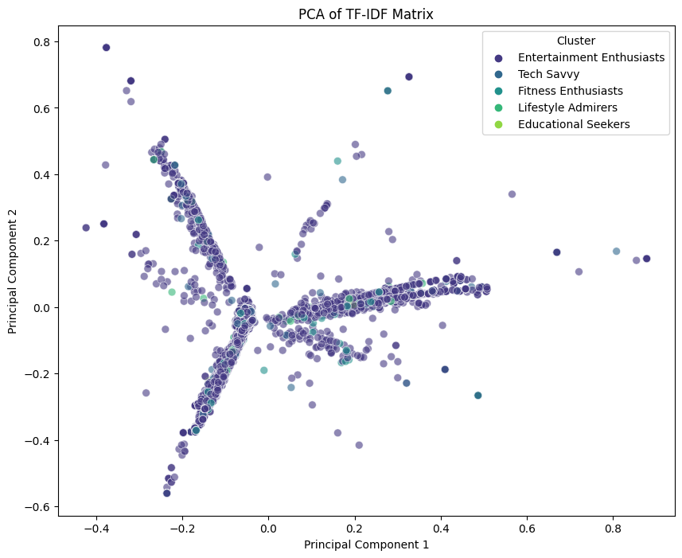

```python
from sklearn.decomposition import PCA
import matplotlib.pyplot as plt
import seaborn as sns

# Reduce dimensionality for visualization using PCA
pca = PCA(n_components=2)
reduced_data = pca.fit_transform(tfidf_review_matrix.toarray())

# Create a DataFrame for the reduced data
df_reduced = pd.DataFrame(reduced_data, columns=['PC1', 'PC2'])
df_reduced['cluster'] = df_tiktok_app_reviews_subset['cluster']

# Map cluster numbers to names
cluster_labels = {
    0: "Entertainment Enthusiasts",
    1: "Educational Seekers",
    2: "Lifestyle Admirers",
    3: "Tech Savvy",
    4: "Fitness Enthusiasts"
}

# Add cluster names to the DataFrame
df_reduced['cluster_name'] = df_reduced['cluster'].map(cluster_labels)

# Plot the clusters
plt.figure(figsize=(10, 8))
sns.scatterplot(x='PC1', y='PC2', hue='cluster_name', data=df_reduced, palette='viridis', s=50, alpha=0.6)
plt.title('PCA of TF-IDF Matrix')
plt.xlabel('Principal Component 1')
plt.ylabel('Principal Component 2')
plt.legend(title='Cluster')
plt.show()
```

```python
from sklearn.manifold import TSNE

# Reduce dimensionality for visualization using t-SNE
tsne = TSNE(n_components=2, random_state=42)
reduced_data_tsne = tsne.fit_transform(tfidf_review_matrix.toarray())

# Create a DataFrame for the reduced data
df_reduced_tsne = pd.DataFrame(reduced_data_tsne, columns=['Dim1', 'Dim2'])
df_reduced_tsne['cluster'] = df_tiktok_app_reviews_subset['cluster']

# Add cluster names to the DataFrame
df_reduced_tsne['cluster_name'] = df_reduced_tsne['cluster'].map(cluster_labels)

# Plot the clusters
plt.figure(figsize=(10, 8))
sns.scatterplot(x='Dim1', y='Dim2', hue='cluster_name', data=df_reduced_tsne, palette='viridis', s=50, alpha=0.6)
plt.title('t-SNE of TF-IDF Matrix')
plt.xlabel('Dimension 1')
plt.ylabel('Dimension 2')
plt.legend(title='Cluster')
plt.show()
```

[output not shown]

### Model Training

Now that you have labeled data, you can train a supervised model (Naive Bayes, Logistic Regression) to predict these labels.

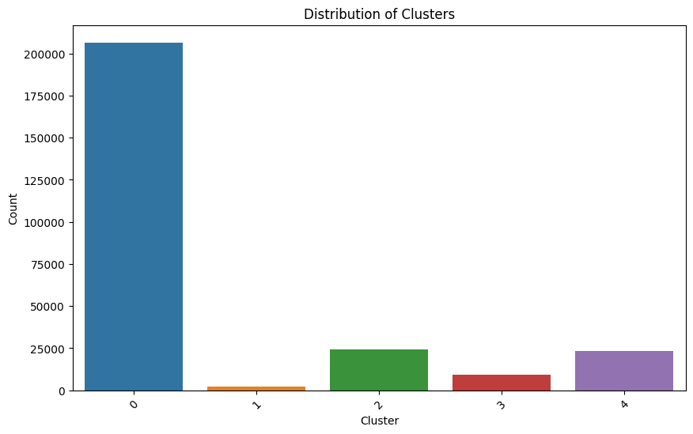

```python
from sklearn.cluster import KMeans
import matplotlib.pyplot as plt
import seaborn as sns

# Apply K-Means clustering
n_clusters = 5  # Adjust the number of clusters as needed
kmeans = KMeans(n_clusters=n_clusters, random_state=42)
kmeans.fit(tfidf_review_matrix)

# Add cluster labels to the DataFrame
df_tiktok_app_reviews_subset['cluster'] = kmeans.labels_

# Count the occurrences of each cluster
cluster_counts = df_tiktok_app_reviews_subset['cluster'].value_counts()

# Plot the distribution of clusters
plt.figure(figsize=(10, 6))
sns.barplot(x=cluster_counts.index, y=cluster_counts.values)
plt.title('Distribution of Clusters')
plt.xlabel('Cluster')
plt.ylabel('Count')
plt.xticks(rotation=45)
plt.show()
```

```python
# Review top terms in each cluster
def get_top_terms_per_cluster(tfidf_matrix, labels, n_terms=10):
    df = pd.DataFrame(tfidf_matrix.toarray(), columns=tfidf_vectorizer.get_feature_names_out())
    df['cluster'] = labels
    top_terms = {}
    for cluster in range(n_clusters):
        cluster_terms = df[df['cluster'] == cluster].drop(columns=['cluster']).mean().sort_values(ascending=False)[:n_terms]
        top_terms[cluster] = cluster_terms.index.tolist()
    return top_terms

top_terms_per_cluster = get_top_terms_per_cluster(tfidf_review_matrix, kmeans.labels_)
print(top_terms_per_cluster)
```

[output not shown]

```python
# Example cluster labels based on the top terms review
cluster_labels = {
    0: "Entertainment Enthusiasts",
    1: "Educational Seekers",
    2: "Lifestyle Admirers",
    3: "Tech Savvy",
    4: "Fitness Enthusiasts"
}

df_tiktok_app_reviews_subset['interest_category'] = df_tiktok_app_reviews_subset['cluster'].map(cluster_labels)
```

## 7. Train a Supervised Model

```python
Now that you have labeled data, you can train a supervised model (Naive Bayes, Logistic Regression) to predict these labels.
```

```python
from sklearn.model_selection import train_test_split
from sklearn.naive_bayes import MultinomialNB
from sklearn.linear_model import LogisticRegression
from sklearn.metrics import accuracy_score, precision_score, recall_score, f1_score

# Split the data
X = df_tiktok_app_reviews_subset['preprocessed_review_text']
y = df_tiktok_app_reviews_subset['interest_category']

X_tfidf = tfidf_vectorizer.transform(X)
X_train, X_test, y_train, y_test = train_test_split(X_tfidf, y, test_size=0.2, random_state=42)

# Train Naive Bayes
nb_model = MultinomialNB()
nb_model.fit(X_train, y_train)

# Train Logistic Regression
lr_model = LogisticRegression(max_iter=1000)
lr_model.fit(X_train, y_train)

# Evaluate Naive Bayes
nb_y_pred = nb_model.predict(X_test)
nb_accuracy = accuracy_score(y_test, nb_y_pred)
nb_precision = precision_score(y_test, nb_y_pred, average='weighted')
nb_recall = recall_score(y_test, nb_y_pred, average='weighted')
nb_f1 = f1_score(y_test, nb_y_pred, average='weighted')

print(f"Naive Bayes - Accuracy: {nb_accuracy:.2f}, Precision: {nb_precision:.2f}, Recall: {nb_recall:.2f}, F1-Score: {nb_f1:.2f}")

# Evaluate Logistic Regression
lr_y_pred = lr_model.predict(X_test)
lr_accuracy = accuracy_score(y_test, lr_y_pred)
lr_precision = precision_score(y_test, lr_y_pred, average='weighted')
lr_recall = recall_score(y_test, lr_y_pred, average='weighted')
lr_f1 = f1_score(y_test, lr_y_pred, average='weighted')

print(f"Logistic Regression - Accuracy: {lr_accuracy:.2f}, Precision: {lr_precision:.2f}, Recall: {lr_recall:.2f}, F1-Score: {lr_f1:.2f}")
```

```
Naive Bayes - Accuracy: 0.96, Precision: 0.96, Recall: 0.96, F1-Score: 0.95
Logistic Regression - Accuracy: 1.00, Precision: 1.00, Recall: 1.00, F1-Score: 1.00
```

Make Predictions on a Subset of Reviews Next, let's make predictions on a subset of the data and display some reviews with their predicted categories:

```python
import pandas as pd

# Select a sample of reviews to display
sample_reviews = df_tiktok_app_reviews_subset.sample(n=5, random_state=42)

# Make predictions using the best performing model (e.g., Logistic Regression)
sample_reviews['predicted_interest_category'] = lr_model.predict(tfidf_vectorizer.transform(sample_reviews['preprocessed_review_text']))

# Display the sample reviews with predicted interest categories
for idx, row in sample_reviews.iterrows():
    print(f"Review: {row['review_text']}")
    print(f"Predicted Interest Category: {row['predicted_interest_category']}")
    print("\n")
```

```
Review: Its addicting and i love it alot
Predicted Interest Category: Entertainment Enthusiasts


Review: Widked app, cant fault anything with it. Just need to spend some time to get around with all filters ect... but its a fun app for everyone!
Predicted Interest Category: Entertainment Enthusiasts


Review: I love this app it is really fun to do
Predicted Interest Category: Fitness Enthusiasts


Review: Helps me with stress
Predicted Interest Category: Entertainment Enthusiasts


Review: Its good but the app likeis better
Predicted Interest Category: Entertainment Enthusiasts
```

In this example output, you can see five sample customer reviews along with their predicted interest categories. This provides a practical demonstration of how the model can be used to categorize user interests based on their review texts.

## Conclusion and Future Work

Currently we used Clustering and manual method for arriving at labels/user interest categories which doesn’t seem to provide meaningful results.

As a next step we are going to use pre-trained model such zero-shot-classification for annotating the dataset into user interest profiles and use it for training the model.

We used TF-IDF vectorizer for feature extraction because it was fast and efficient for large datasets but it doesn’t provide deep contextual information. So, we will use BERT embeddings in the future